# Week 9 Regression Discontinuity Designs

Author

Zhe Chen

# The Idea of RDD $\bigstar$

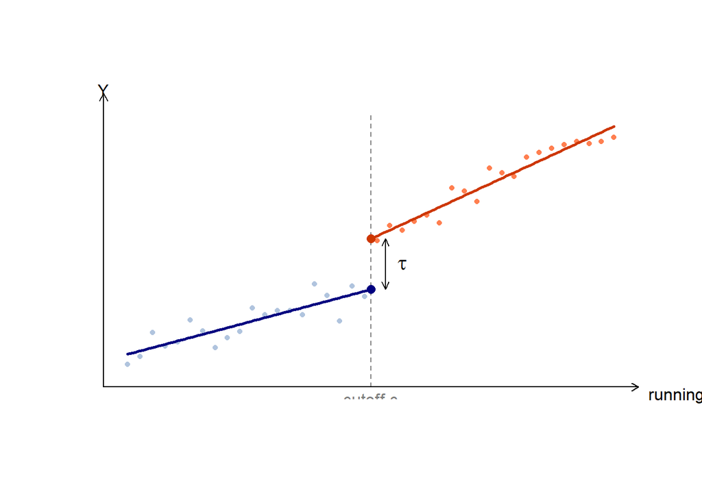

**Just below and just above the cutoff, units are essentially identical**, except that one group got the treatment. The jump in the outcome at $c$ is the effect.

$$\begin{array}{lll}\hline
\text{Design} & \text{Comparable units} & \text{Needs}\\ \hline
\text{Matching, weighting (Week 6)} & \text{same }X,\text{ both treatments observed} & \text{overlap, }0<e(x)<1\\
\text{IV (Week 7)} & \text{moved by }Z,\text{ which moves only }D & \text{exclusion, monotonicity}\\
\text{RD (today)} & \text{just either side of a cutoff in }X & \text{continuity at the cutoff}\\ \hline
\end{array}$$
**Outline**

# Sharp RD

Examples:

- Does winning a Senate seat help the party keep it six years later?
  - $X_i$: Democratic margin of victory at $t$, in points ($c$ = 0);
  - $Y_i$: Democratic vote share in the same seat at $t + 6$.
- Turning 21: Does drinking kill young adults? U.S. alcohol becomes legal on the 21st birthday.
  - Running variable: age in days
  - Cutoff: 21.

## Setup and Identification $\bigstar$

A **running variable (or forcing variable)** $X_i$ determines treatment deterministically:

$$D_i=\mathbf{1}\{X_i\ge c\}.$$

**TipIndicator Function**

$$D_i=\mathbb{1}\{X_i\ge c\}=
\begin{cases}
1, & X_i\ge c \quad \text{(treated)}\\
0, & X_i<c \quad \text{(untreated)}
\end{cases}$$

Write $m_d(x)=E[Y_i(d)\mid X_i=x]$ for the two potential-outcome curves.

**Continuity assumption (Hahn, Todd, and van der Klaauw 2001)**

$m_1(x)$ and $m_0(x)$ are continuous in $x$ at $x=c$.

Then

$$\tau_{RD}=\lim_{x\downarrow c}E[Y_i\mid X_i=x]-\lim_{x\uparrow c}E[Y_i\mid X_i=x]=E[Y_i(1)-Y_i(0)\mid X_i=c].$$

- **Not assumed:** anything about the shape of $E[Y\mid X]$ away from the cutoff, or ignorability anywhere else.
- **Positivity fails at every** $x$: $\Pr(D=1\mid X=x)$ is 0 or 1. Identification comes from continuity, not overlap, which is why the estimand is local to $c$.

## Two Curves, Each Seen on One Side

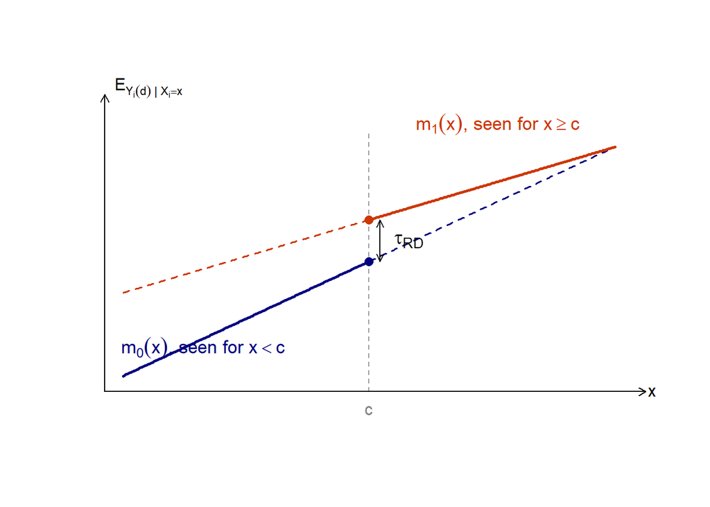

The observed regression $E[Y_i\mid X_i=x]$ follows $m_0$ to the left of $c$ and $m_1$ to the right; it jumps at $c$ by $m_1(c)-m_0(c)$.

The dashed halves are never observed. Away from $c$, the gap between the curves, $\tau(x)$, is not identified without further assumptions.

## What Continuity Rules Out

Continuity fails when something other than $D$ changes at $c$.

- **A second treatment at the same cutoff.** An age threshold that grants a pension and also lowers a tax; a district boundary where schools, police, and taxes all change. The jump is the effect of the bundle.
- **Sorting.** If people who would do well anyway can place themselves just above $c$, the units just above differ from those just below in $Y_i(0)$ itself, and $m_0$ jumps.
- **Selection of the cutoff on outcomes.** An agency that sets $c$ where it expects a change, after seeing the data, builds the jump in.

Continuity is a statement about $Y_i(0)$ and $Y_i(1)$, so it cannot be tested directly. It has **two testable implications**: the density of $X$ and the distribution of pre-determined covariates should not jump at $c$.

## The Estimand Is Local $\bigstar$

$\tau_{RD}$ is the average effect **for units at the cutoff**. Nothing more.

- A scholarship RD tells you about students at the eligibility margin, not about the strongest or weakest applicants.
- Extrapolating away from $c$ requires a functional-form assumption of exactly the kind RD was designed to avoid.
- Compare with the LATE from Week 7: both are estimands you did not choose, determined by the design rather than by the question. State them plainly.
- In exchange, RD is often the most credible observational design there is. The identifying variation is visible in a scatterplot.

Lee (2008)’s reformulation is helpful: if agents cannot perfectly control $X_i$, then treatment near the cutoff is *as good as randomly assigned*, and the design is a local experiment.

## Steps of RDD $\bigstar$

**Target:** $\tau_{RD}=m_1(c)-m_0(c)$, the heights of the two curves *exactly* at the cutoff.

**Problem:** No unit sits exactly at $c$. Each height must be **predicted from units near $c$**.

| Choice | Question | What is at stake | Standard answer |
| --- | --- | --- | --- |
| Shape | Mean, line, or curve? | Mean: biased if the curve slopes; curve: more variance | A line on each side |
| Weights | Closer units count more? | Far units add bias | Triangular kernel |
| Bandwidth | How far from $c$? | Wider: less variance, more bias | Minimize MSE |
| Inference | How sure? | Leftover bias: usual interval too short | Robust bias-corrected |

# Estimation

## Two Ways to Use the Races Near the Cutoff $\bigstar$

Keep the 683 races within h = 17.75 points of a tie (shaded)

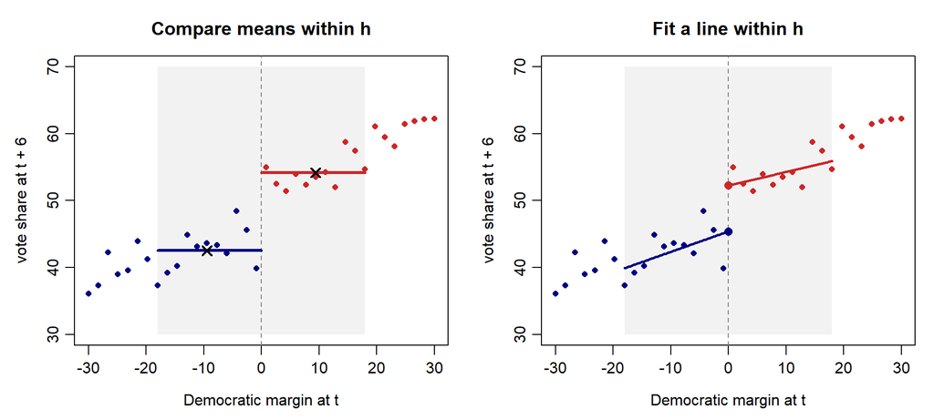

## Comparing Means Overstates

**Goal:** Write the difference in means as the line estimate plus an error.

**Fact:** An OLS line passes through the point of means $(\bar{x},\bar{Y})$. The normal equation for the intercept says the residuals sum to zero:

$$\sum_i(Y_i-\hat{\mu}-\hat{\beta}x_i)=0\quad\Longrightarrow\quad \bar{Y}=\hat{\mu}+\hat{\beta}\bar{x}.$$

Apply it on each side, with $x_i=X_i-c$ and $\bar{x}_{\pm}$ the mean distance (uniform kernel):

$$\begin{aligned}
\bar{Y}_+ &= \hat{\mu}_+ + \hat{\beta}_+\bar{x}_+ && \text{the line above passes through its means}\\
\bar{Y}_- &= \hat{\mu}_- + \hat{\beta}_-\bar{x}_- && \text{the line below, likewise}\\
\bar{Y}_+-\bar{Y}_- &= \underbrace{(\hat{\mu}_+-\hat{\mu}_-)}_{\hat{\tau}_{\mathrm{linear}}}+\hat{\beta}_+\bar{x}_+-\hat{\beta}_-\bar{x}_- && \text{subtract}\\
&=\hat{\tau}_{\mathrm{linear}}+\hat{\beta}_+\bar{x}_++\hat{\beta}_-|\bar{x}_-| && \bar{x}_-<0\text{ below the cutoff}
\end{aligned}$$

With upward slopes, both extra terms are positive: the mean above is read to the *right* of $c$ (too high), the mean below to the *left* (too low).

## A Line on Each Side $\bigstar$ (1st Framework)

**In words:**

1. Keep the units within $h$ of the cutoff.
2. On each side, regress $Y$ on the distance to the cutoff, $X_i-c$.
3. Each intercept is the predicted $Y$ *at the cutoff* on that side.
4. $\hat{\tau}$ is the difference between the two intercepts.

$$\hat{\tau}=\hat{\mu}_+-\hat{\mu}_-$$

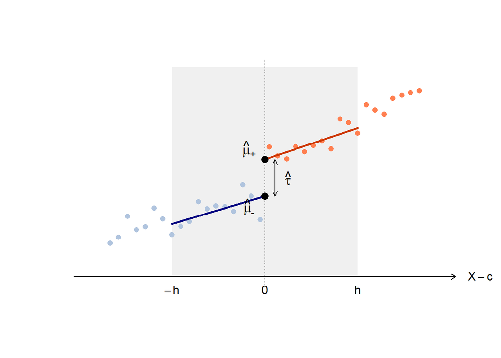

### In One Regression

On the units with $|X_i-c|\le h$ (same answer as two separate fits):

$$Y_i=\mu+\tau D_i+\beta_-(X_i-c)(1-D_i)+\beta_+(X_i-c)D_i+\text{error}$$

$$\begin{array}{ll}\hline
\text{Coefficient} & \text{Meaning}\\ \hline
\mu & \text{predicted }Y\text{ just below the cutoff}\\
\mu+\tau & \text{predicted }Y\text{ just above the cutoff}\\
\tau & \text{the jump at the cutoff: the RD estimate}\\
\beta_-,\ \beta_+ & \text{slopes below and above, free to differ}\\ \hline
\end{array}$$

- **Centre the running variable** at $c$, so that $\tau$ is the gap at the cutoff rather than at $X=0$.
- **Let the slopes differ:** a common slope lets data on one side shape the prediction on the other.

### Shape: Why a Line and Not a Curve?

More flexible fits follow the curve better near $c$ but are noisier.

Example:

$$\begin{array}{lrrl}\hline
\text{Fit on each side} & \text{Estimate} & \text{s.e.} & \text{Problem}\\ \hline
\text{Mean (degree 0)} & 9.68 & 0.80 & \text{biased whenever the curve slopes}\\
\text{Line (degree 1)} & 7.41 & 1.46 & \text{biased only where the curve bends}\\
\text{Quadratic (degree 2)} & 8.32 & 2.06 & \text{s.e. 40\% larger}\\ \hline
\end{array}$$

- A line removes the slope bias of comparing means and costs a modest amount of precision. A quadratic buys little more and costs a lot.
- The quadratic still has a job: **it is how the bias of the line is estimated (inference section)**.

## Weights: Closer Races Count More

A race won by 2 points tells us more about a tie than one won by 16. The **triangular kernel** weights each unit by how close it is:

$$K\left(\frac{X_i-c}{h}\right)=1-\frac{|X_i-c|}{h}$$

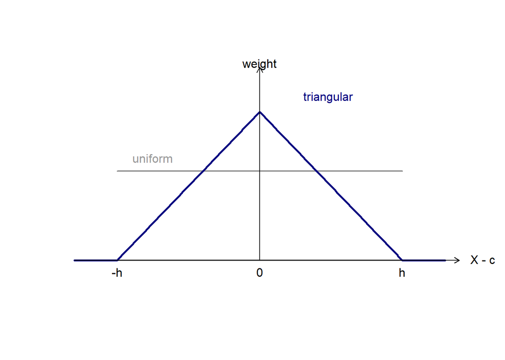

for $|X_i-c|\le h$, zero beyond.

- **Fitting the line becomes weighted least squares.**
- Races within $h/2$ of a tie are 59% of the races, 80% of the weight.
- Uniform weights give 7.09, triangular 7.41. **The kernel matters little; the bandwidth matters much more.**

## Bandwidth: How Far From the Cutoff to Look?

The same local linear fit with three bandwidths (shaded)

[figure not shown]

- Narrow: only near-ties, so the line describes the right races, but few of them. The estimate is noisy.
- Wide: many races and a small s.e., but one straight line must now cover landslides too. If the curve bends, the line misses at $c$.

## Bias and Variance: Definitions $\bigstar$

$\hat{\tau}_h$, the estimate at bandwidth $h$, varies from sample to sample:

$$\begin{aligned}
\operatorname{Bias}(\hat{\tau}_h)&=E[\hat{\tau}_h]-\tau && \text{average estimate minus the truth}\\
\operatorname{Var}(\hat{\tau}_h)&=E\left[(\hat{\tau}_h-E[\hat{\tau}_h])^2\right] && \text{scatter around that average}\\
\operatorname{MSE}(\hat{\tau}_h)&=E\left[(\hat{\tau}_h-\tau)^2\right] && \text{average squared distance from the truth}
\end{aligned}$$

**The decomposition:**

$$\begin{aligned}
\operatorname{MSE}(\hat{\tau}_h)
&=E\left[\left((\hat{\tau}_h-E[\hat{\tau}_h])+(E[\hat{\tau}_h]-\tau)\right)^2\right]
&& \text{add and subtract }E[\hat{\tau}_h]\\
&=E\left[(\hat{\tau}_h-E[\hat{\tau}_h])^2\right]+(E[\hat{\tau}_h]-\tau)^2
&& \text{expand the square}\\
&\quad+2(E[\hat{\tau}_h]-\tau)\underbrace{E[\hat{\tau}_h-E[\hat{\tau}_h]]}_{=0}
&& \text{the bias is a constant}\\
&=\operatorname{Var}(\hat{\tau}_h)+\operatorname{Bias}(\hat{\tau}_h)^2
\end{aligned}$$

In RD, **bias grows with $h$** (the line misses the curve at $c$) and **variance falls with $h$** (more units): the bandwidth trades one for the other.

### Bandwidth $\bigstar$

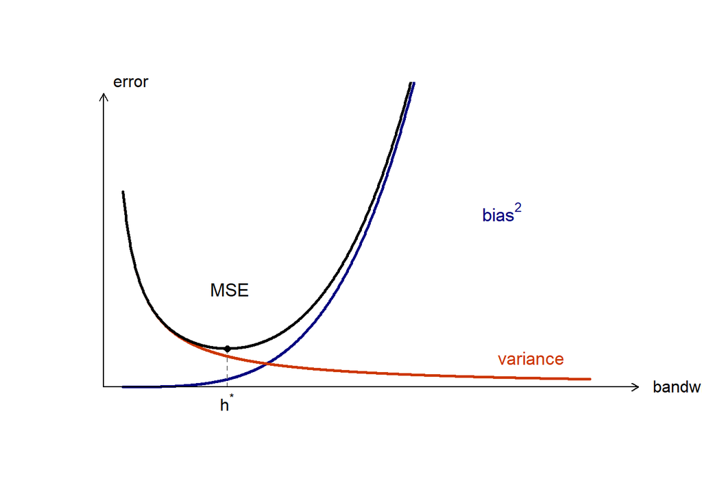

### Decomposition of the Bias

#### Step 1: the Picture $\bigstar$

**Goal:** Compute $\operatorname{Bias}(\hat{\tau})=E[\hat{\tau}]-\tau$, where $\tau=m_1(c)-m_0(c)$ and $\hat{\tau}=\hat{\mu}_+-\hat{\mu}_-$:

$$E[\hat{\tau}]-\tau=\left(E[\hat{\mu}_+]-m_1(c)\right)-\left(E[\hat{\mu}_-]-m_0(c)\right)$$

Both sides work the same way; take the side above: uniform kernel, $X$ spread evenly, $u_i=(X_i-c)/h\in[0,1]$. OLS is linear in $Y$ and $E[Y_i\mid X_i]=m_1(X_i)$, so $E[\hat{\mu}_+]$ is the intercept of the line fitted to the curve $m_1$ itself.

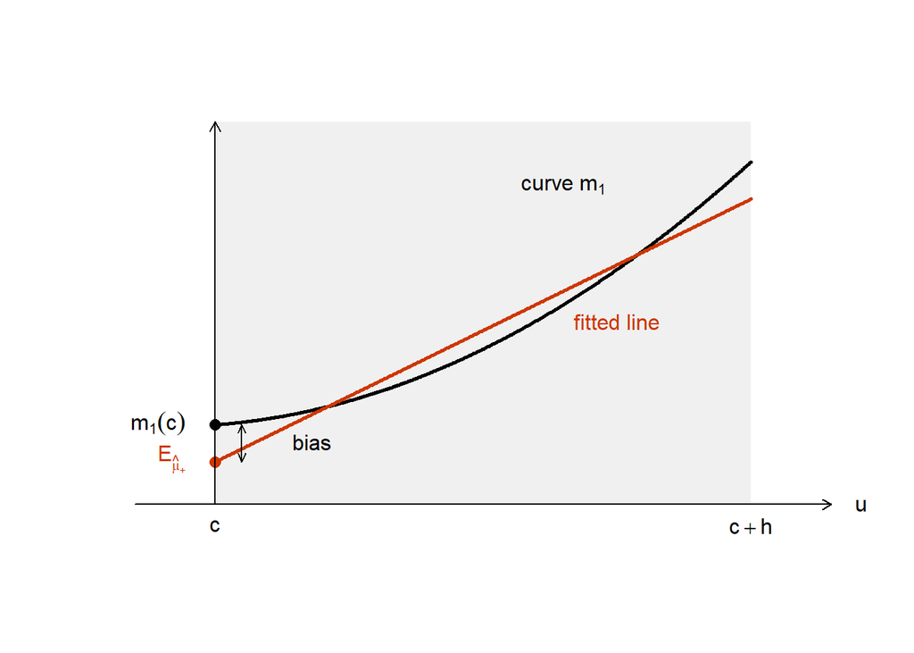

- **The bias** is the gap at $c$ between the curve and the line fitted to it.
- **A straight curve:** the line lies on it, no gap. **A bent curve:** the line cuts across the bend and misses at the edge.
- To compute the gap, we need a formula for $m_1$. We do not have one.

#### Step 2: Use a Parabola

**Taylor:** Near $c$, a smooth curve is close to a parabola built from its height, slope, and bend at $c$. With $X=c+hu$:

$$m_1(c+hu)\approx\underbrace{m_1(c)}_{a}+\underbrace{m_1'(c)h}_{b}u+\underbrace{\frac{1}{2}m_1''(c)h^2}_{q}u^2$$

- **Why this helps:** We cannot fit a line to an unknown curve by hand, but we can fit one to a parabola.
- **Why expand at $c$:** The target then appears in the formula, $a=m_1(c)$.
- **Left out:** $\frac{1}{6}m_1'''(c)h^3u^3+\cdots$. We assume this is negligible inside the window: on $[c,c+h]$ the curve is close to a parabola.

#### Step 3: Plug the Parabola Into OLS

**Goal:** $E[\hat{\mu}_+]-m_1(c)$. $E[\hat{\mu}_+]$ is the intercept of the OLS line of $a+bu+qu^2$ on $u$ (Steps 1–2), with $u$ spread evenly on $[0,1]$.

$$\begin{aligned}
\text{slope}
&=\frac{\operatorname{Cov}(u,a+bu+qu^2)}{\operatorname{Var}(u)}
&& \text{OLS slope}\\
&=\frac{b\operatorname{Var}(u)+q\operatorname{Cov}(u,u^2)}{\operatorname{Var}(u)}
=b+q
&& a\text{ is constant; }\operatorname{Cov}(u,u^2)=\operatorname{Var}(u)\\[6pt]
E[\hat{\mu}_+]
&=E[a+bu+qu^2]-(b+q)E[u]
&& \text{OLS line passes through the means}\\
&=a+\frac12 b+\frac13 q-\frac12 b-\frac12 q
=a-\frac16 q
&& E[u]=\frac12,\ E[u^2]=\frac13\\[6pt]
E[\hat{\mu}_+]-m_1(c)
&=-\frac16 q=-\frac{1}{12}m_1''(c)h^2
&& a=m_1(c),\ q=\frac12 m_1''(c)h^2
\end{aligned}$$

- **$b$ cancels:** the line gets the level and slope right. Only the bend $q$ leaves a gap at the cutoff.

#### Step 4: Both Sides Together $\bigstar$

Above the cutoff (Step 3): $E[\hat{\mu}_+]-m_1(c)=-\frac{1}{12}m_1''(c)h^2$.

Below the cutoff, $u\in[-1,0]$: the same steps give $E[\hat{\mu}_-]-m_0(c)=-\frac{1}{12}m_0''(c)h^2$.

$$\begin{aligned}
\operatorname{Bias}(\hat{\tau})
&=\left(E[\hat{\mu}_+]-m_1(c)\right)-\left(E[\hat{\mu}_-]-m_0(c)\right) && \text{Step 1}\\
&=\underbrace{-\frac{1}{12}\left(m_1''(c)-m_0''(c)\right)}_{B}h^2
\end{aligned}$$

- **Bias $=Bh^2$:** doubling $h$ multiplies its magnitude by 4.
- Straight curves ($m''=0$) give no bias; equal bends on the two sides cancel.
- A triangular kernel or uneven $X$ changes the constant $\frac{1}{12}$, not the leading-order form $Bh^2$.

### Decomposition of the Variance

#### Step 1: The Mean and the Slope

**Goal:** $\operatorname{Var}(\hat{\mu}_+)$, with $m$ units above $c$ and $u$ spread evenly on $[0,1]$. Assume $Y_i=m_1(X_i)+\epsilon_i$, independent errors, $\operatorname{Var}(Y_i\mid X_i)=\sigma_+^2$. Given $X=(X_1,\ldots,X_m)$, $m_1(X_i)$ and $u_i$ are fixed; only the $\epsilon_i$ are random.

$$\begin{aligned}
\operatorname{Var}(\bar Y\mid X)
&=\operatorname{Var}\left(\frac{1}{m}\sum_i\epsilon_i\mid X\right)
=\frac{\sigma_+^2}{m}
&& \text{drop the fixed }m_1(X_i);\text{ independence}\\[8pt]
\operatorname{Var}(\hat{\beta}\mid X)
&=\operatorname{Var}\left(\frac{\sum_i(u_i-\bar u)\epsilon_i}{\sum_i(u_i-\bar u)^2}\mid X\right)
&& \text{OLS slope; drop the fixed part}\\[8pt]
&=\frac{\sigma_+^2\sum_i(u_i-\bar u)^2}{\left(\sum_i(u_i-\bar u)^2\right)^2}
=\frac{\sigma_+^2}{m\operatorname{Var}(u)}
&& \operatorname{Var}(u)=\frac{1}{m}\sum_i(u_i-\bar u)^2\\[8pt]
\operatorname{Cov}(\bar Y,\hat{\beta}\mid X)&=0
&& \text{see below}
\end{aligned}$$

- A high error always raises $\bar Y$, but raises the slope if the unit is right of $\bar u$ and lowers it if left. With independent, equal-variance errors, these cancel.

#### Step 2: One Side

The OLS intercept is $\hat{\mu}_+=\bar Y-\hat{\beta}\bar u$, so with Step 1:

$$\begin{aligned}
\operatorname{Var}(\hat{\mu}_+\mid X)
&=\operatorname{Var}(\bar Y\mid X)+\bar u^2\operatorname{Var}(\hat{\beta}\mid X)-2\bar u\operatorname{Cov}(\bar Y,\hat{\beta}\mid X)
&& \text{variance of a difference}\\[6pt]
&=\frac{\sigma_+^2}{m}+\bar u^2\frac{\sigma_+^2}{m\operatorname{Var}(u)}
&& \text{Step 1}\\[6pt]
&=\frac{\sigma_+^2}{m}\left(1+\frac{1/4}{1/12}\right)
=\frac{4\sigma_+^2}{m}
&& \bar u=\frac12,\ \operatorname{Var}(u)=\frac1{12}
\end{aligned}$$

- **More noise $\sigma_+^2$:** larger variance. **More units $m$:** smaller variance.
- A wider $h$ brings in more units, so $m$ grows; $\sigma_+^2$ is the noise around the curve and does not depend on $h$.

#### Step 3: Both Sides Together

How many units fall in $[c,c+h]$? With $f$ the density of $X$:

$$\begin{aligned}
m &\approx n\Pr(c\le X\le c+h)=n\int_c^{c+h}f(x)\,dx && \text{expected count = }n\times\text{probability}\\
&\approx nf(c)h && f\approx f(c)\text{ on the window}\\[6pt]
\operatorname{Var}(\hat{\mu}_+) &\approx \frac{4\sigma_+^2}{nf(c)h} && \text{Step 2, substitute }m\\[6pt]
\operatorname{Var}(\hat{\tau}) &= \operatorname{Var}(\hat{\mu}_+)+\operatorname{Var}(\hat{\mu}_-) && \text{the two sides use different units}\\
&\approx \underbrace{\frac{4(\sigma_+^2+\sigma_-^2)}{f(c)}}_{V}\cdot\frac{1}{nh}
\end{aligned}$$

- **Variance $=V/(nh)$:** doubling $h$ halves the variance.
- More noise ($\sigma^2$) or fewer units near $c$ ($f(c)$ small): more variance.

### MSE-Optimal Bandwidth

#### Derivation

**Goal:** Find the bandwidth $h$ that minimizes

$$\operatorname{MSE}(h)=\underbrace{B^2h^4}_{\text{bias}^2}+\underbrace{\frac{V}{nh}}_{\text{variance}}.$$

Differentiate each term with respect to $h$:

$$\begin{aligned}
\frac{d}{dh}B^2h^4 &= 4B^2h^3 && \text{power rule}\\
\frac{d}{dh}\frac{V}{nh} &= \frac{V}{n}\frac{d}{dh}h^{-1}=-\frac{V}{nh^2} && \frac{V}{n}\text{ is constant}
\end{aligned}$$

Set the first derivative of MSE equal to zero:

$$\begin{aligned}
0 &= 4B^2h^3-\frac{V}{nh^2} && \text{first-order condition}\\
4B^2h^5 &= \frac{V}{n} && \text{multiply by }h^2\\
h^* &= \left(\frac{V}{4B^2n}\right)^{1/5}
=\left(\frac{V}{4B^2}\right)^{1/5}n^{-1/5}
&& \text{take the fifth root}
\end{aligned}$$

#### Formula

$$h^*=\left(\frac{V}{4B^2}\right)^{1/5}n^{-1/5},\qquad V=\frac{4(\sigma_+^2+\sigma_-^2)}{f(c)},\qquad B=-\frac{1}{12}\left(m_1''(c)-m_0''(c)\right)$$

- **Wider** when the noise $\sigma^2$ is large or few units sit near $c$ ($f(c)$ small): more data are needed to tame the variance.
- **Narrower** when the curves bend sharply at $c$ ($B$ large): a line is only good close to $c$.
- $B$ and $V$ are unknown: a pilot fit estimates $m''$, $\sigma^2$, and $f(c)$ and plugs them in (Imbens and Kalyanaraman 2012; Calonico, Cattaneo, and Titiunik 2014).
- $h^*$ shrinks slowly: ten times the data narrows it by a factor of $10^{1/5}\approx1.6$.
- **Senate:** $\hat h^*=17.75$ points on both sides.

### Example: Bandwidth Sensitivity

Conventional estimate and robust bias-corrected 95% interval:

$$\begin{array}{lrrll}\hline
h & \text{Estimate} & {\text{Robust 95\% interval}} & {\text{Effective }n\text{ (below, above)}}\\ \hline
5 & 12.27 & [7.93,\ 19.77] & 128,\ 117\\
10 & 7.98 & [4.39,\ 13.11] & 245,\ 206\\
12.41\ (h_{CER}) & 7.63 & [4.07,\ 11.29] & 284,\ 248\\
17.75\ (h_{MSE}) & 7.41 & [4.09,\ 10.92] & 360,\ 323\\
30 & 7.28 & [5.13,\ 10.71] & 474,\ 457\\
50 & 6.48 & [4.87,\ 9.70] & 565,\ 562\\ \hline
\end{array}$$

- **Stable between $h=10$ and $50$:** every interval excludes zero.
- At $h=5$ the estimate rises, with 245 elections: noise, and the interval says so.
- **$h_{MSE}$:** the MSE-optimal bandwidth. **$h_{CER}$:** the coverage-error-optimal bandwidth, narrower, chosen so the interval covers $\tau$ as close to 95% of the time as possible (Calonico, Cattaneo, and Farrell 2020).

## Inference

### Standard Error

**Goal:** $\operatorname{se}(\hat{\tau})$, for the usual 95% interval $\hat{\tau}\pm1.96\,\operatorname{se}$. Revisit the variance:

$$\begin{aligned}
\operatorname{Var}(\hat{\tau}\mid X)
&=\operatorname{Var}(\hat{\mu}_+\mid X)+\operatorname{Var}(\hat{\mu}_-\mid X)
&& \text{the two sides use different units}\\
&=\frac{4\sigma_+^2}{m_+}+\frac{4\sigma_-^2}{m_-}
&& \text{variance, Step 2, on each side}\\[6pt]
\widehat{\operatorname{se}}(\hat{\tau})
&=\sqrt{\frac{4\hat{\sigma}_+^2}{m_+}+\frac{4\hat{\sigma}_-^2}{m_-}}
&& \hat{\sigma}_\pm^2:\text{ residual variance of each side's line}
\end{aligned}$$

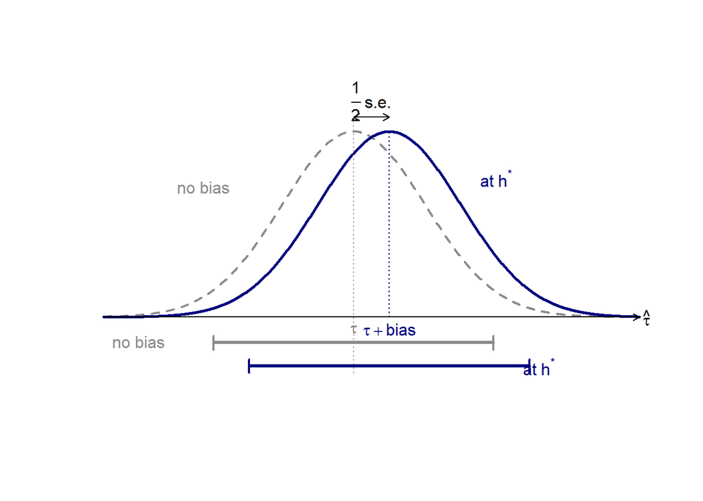

- At $h^*$, the estimates average $\tau+\operatorname{Bias}$, where $\operatorname{Bias}=\frac{1}{2}\operatorname{se}$ (next frame). Thus, the interval is shifted upward: **both endpoints are too high**.
- **A shifted interval misses $\tau$ more often:** it contains $\tau$ in about 92% of samples, rather than 95%.
- Three repairs: undersmoothing, robust bias correction, and honest confidence intervals.

### Three Repairs

Example: Senate data

| Method | What it does about the bias | $h$ | 95% interval |
| --- | --- | --- | --- |
| None (usual interval) | Ignores it; covers 92% at $h_{MSE}$ | 17.75 | [4.56, 10.27] |
| **1. Undersmooth** | Shrinks it: smaller $h$, bias small relative to the SE | 10 | [4.38, 11.59] |
| **2. Robust bias correction** | Estimates it, subtracts it, widens the SE | 17.75 | [4.09, 10.92] |
| … at $h_{CER}$ | Same repair, $h$ chosen for coverage, not MSE | 12.41 | [4.07, 11.29] |
| **3. Honest interval** | Bounds it ($\lvert m''\rvert\le M$), widens by the worst case | 9.84 | [3.83, 12.23] |

- `rdrobust`’s “robust” interval (and the sensitivity table) is **repair 2**. $h_{CER}$ is not a fourth repair: it is the bandwidth for repair 2.
- **Undersmoothing** has no automatic rule in this illustration for how much smaller $h$ should be; repairs 2 and 3 provide more explicit procedures.

#### Repair 2

The bias of the line is $Bh^2$, and $B$ depends on how much the curves *bend* at $c$ (Calonico, Cattaneo, and Titiunik 2014). So:

1. **Estimate the bend.** Fit a quadratic on each side (with a pilot bandwidth $b$, chosen to estimate the bend with minimum MSE; usually wider than $h$). Its curvature gives $\hat B$.
2. **Subtract the estimated bias:**

   $$\hat{\tau}^{bc}=\hat{\tau}_h-\hat B h^2.$$
3. **Widen the interval.** $\hat B$ is itself estimated with noise, so $\hat{\tau}^{bc}$ is noisier than $\hat{\tau}_h$. The robust standard error counts that extra noise.
- The **robust interval** is centred on $\hat{\tau}^{bc}$, not on $\hat{\tau}_h$. Senate: $\hat{\tau}_h=7.41$, $\hat{\tau}^{bc}=7.51$, robust interval $[4.09,10.92]$, whose midpoint is approximately $7.51$.
- **Common practice** (Cattaneo, Idrobo, and Titiunik 2020): report $\hat{\tau}_h$ (smaller MSE, since estimating $\hat B$ adds noise) with the robust interval, and say so. `rdrobust` prints both rows.

## Estimation Guide $\bigstar$

1. **Plot binned means** of $Y$ against $X$, with the cutoff marked. The jump should be visible before any estimate.
2. **Estimate with a line on each side**, triangular weights, $h_{MSE}$: $\hat{\tau}=7.41$ points, $h=17.75$.
3. **Interval:** robust bias-corrected, $[4.09,10.92]$ (at $h_{CER}$: $[4.07,11.29]$).
4. **Report the units used:** 360 races below, 323 above.
5. **Show the choices do not drive the result:** $h$ from 10 to 50 gives 6.5 to 8.0; a quadratic gives 8.32.

`rdrobust(y = vote, x = margin)` gives the estimate, interval, and units; `rdplot(vote, margin)` gives the plot.

# Covariates

Same local regression (units within $h$, kernel weights), plus covariates $Z_i$:

$$Y_i=\alpha+\tau D_i+\beta_-(X_i-c)(1-D_i)+\beta_+(X_i-c)D_i+Z_i'\gamma+\epsilon_i$$

$Z_i$ must be **pre-determined**: fixed before the cutoff is crossed. Turning 21: sex, race, schooling.

- If $Z$ is continuous at $c$, it is balanced across the cutoff, so $\hat{\tau}$ should barely change. What changes is the s.e.: $Z$ explains part of $Y$, so less noise is left.
- If $\hat{\tau}$ does change a lot, $Z$ jumps at $c$: a sign of sorting, not an improvement. (Formal balance test: validity section.)
- **Rules:** $Z$ enters on its own (no $D\times Z$ interaction); never a post-treatment $Z$.

**Covariates are for precision only.** They must be *pre-determined*, they should enter additively (not interacted with $D$), and the estimate should barely move when you add them. If it moves a lot, the design is in trouble, not improved (Calonico et al. 2019).

**Effective sample size:** Report the number of observations *inside the bandwidth* on each side. An RD with $n=100{,}000$ often has 400 observations doing the work, and the standard errors should be read accordingly. Senate: 1,297 races, 683 do the work.

# Validity

## The Threat: Manipulation $\bigstar$

Continuity fails if units can *precisely control* which side of the cutoff they land on: retaking a test until you pass, reporting income just under a threshold, or a firm holding hiring just below a regulatory headcount.

- **Imprecise control is fine.** Lee (2008)’s insight is that if agents cannot control $X$ to the last decimal, assignment near the cutoff is as good as random even though agents influence $X$.
- **Density test** (McCrary 2008; Cattaneo, Jansson, and Ma 2020): Is the density of $X$ continuous at $c$? A spike on the advantaged side is direct evidence of sorting.
- **Covariate smoothness:** Run the RD with *pre-determined covariates as outcomes*. They should show no jump. This is the single most persuasive check, and it is the RD analogue of a balance table.
- **Donut hole:** Drop observations immediately around $c$, where manipulation would concentrate, and see whether the estimate survives.

## Density Test

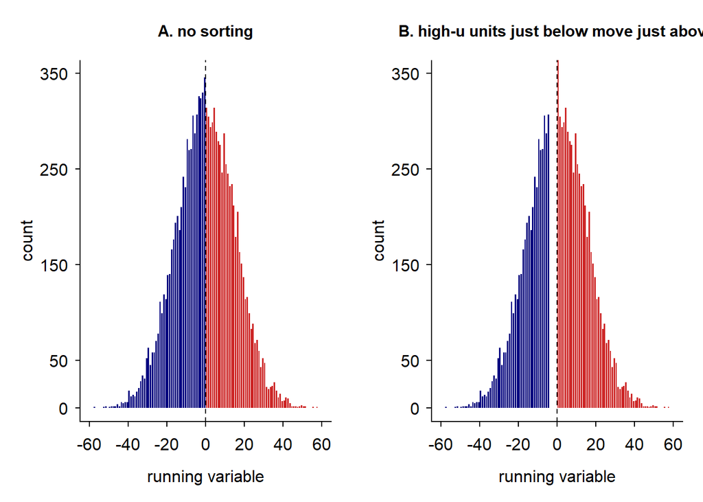

- Two traces: a hole below 0 and a spike above it (**density test**); winners who differed before the race (**balance test**).

**The test.** Estimate the density of $X$ at $c$ separately from each side and compare:

$$T=\frac{\hat f_+(c)-\hat f_-(c)}{\widehat{\mathrm{se}}}\approx N(0,1)\qquad\text{under no sorting}.$$

McCrary (2008) bins $X$ and runs local linear regressions on the bin counts; Cattaneo, Jansson, and Ma (2020) fit a local polynomial to the empirical distribution function, with no bins (`rddensity`).

## Other Checks and Common Errors

**Placebo cutoffs:** Estimate at fake thresholds away from $c$, using only data on one side so the real discontinuity is not picked up. Significant ``effects’’ there mean your procedure finds jumps everywhere.

**Bandwidth sensitivity:** Plot $\hat{\tau}$ against $h$ over a wide range with robust intervals. A result that exists only at one bandwidth is not a result.

**Do not use a high-order global polynomial** (Gelman and Imbens 2019). The implied weights on distant observations are large, oscillating, and indefensible; estimates wander with the degree.

**Do not control for post-treatment covariates**, and do not interact covariates with $D$ unless you mean to estimate heterogeneity.

**Do not report only the conventional interval** at an MSE-optimal bandwidth.

## Local Randomization (2nd Framework)

**Goal:** Treat a small window around $c$ as an experiment, and analyse it as one.

**Assumption:** There is a window $W_0=[c-w,c+w]$ in which:

1. Which units fall above $c$ is as if decided by a coin flip.
2. $Y_i(d)$ does not depend on $X_i$ inside the window.
- **Fisher randomization test:** The difference in means inside $W_0$ estimates the effect, and a Fisher randomization test gives exact $p$-values: reshuffle who is above $c$ among the window’s units, recompute, and compare.
- **Continuity vs. local randomization:** Continuity extrapolates two curves to one point; local randomization assumes a whole window is an experiment. Condition 2 is stronger, which is why $w$ must be small (Sekhon and Titiunik 2017).
- **Discrete running variable:** This approach is natural when $X$ has few values near $c$ (ranks, ages in years), where curve fitting has little to work with.

**TipFisher Randomization Test**

Under the sharp null $H_0:Y_i(1)=Y_i(0)$ for every unit, treatment assignment within the window is as good as random.

1. Calculate the observed treated–control difference in means.
2. Randomly reshuffle treatment labels, preserving the number treated.
3. Recalculate the difference for each assignment.
4. The $p$-value is the proportion of assignments with a difference at least as extreme as observed.

$$p=\Pr\left(|\hat\tau_{\mathrm{perm}}|\geq|\hat\tau_{\mathrm{obs}}|\mid H_0\right)$$

**Key idea:** An unusually large observed difference provides evidence against the sharp null.

**Window**: in nested windows, test balance on pre-determined covariates; take the largest window in which the smallest p-value stays above 0.15 (`rdlocrand::rdwinselect`).

# Fuzzy RD

## Core of Fuzzy RD $\bigstar$

Often crossing the cutoff changes the *probability* of treatment rather than determining it: eligibility is not take-up.

$$\lim_{x\downarrow c}\Pr(D_i=1\mid X_i=x)-\lim_{x\uparrow c}\Pr(D_i=1\mid X_i=x)\in(0,1).$$

**The fuzzy RD estimator is a ratio of two sharp RD estimates:**

$$\tau_{FRD}=\frac{\text{jump in }Y\text{ at }c}{\text{jump in }D\text{ at }c}=\frac{\lim_{x\downarrow c}E[Y_i\mid X_i=x]-\lim_{x\uparrow c}E[Y_i\mid X_i=x]}{\lim_{x\downarrow c}E[D_i\mid X_i=x]-\lim_{x\uparrow c}E[D_i\mid X_i=x]}.$$

- **This is exactly the Wald estimator of Week 7**, with $\mathbb{1}\{X_i\ge c\}$ as the instrument, estimated locally.
- The numerator alone is the **intention-to-treat (ITT) effect** of crossing the cutoff, and it is worth reporting on its own. It needs no first-stage relevance assumption.

## What the Ratio Estimates: Four Types at the Cutoff

Write $D_i(1)$ for the treatment unit $i$ would take just above $c$ and $D_i(0)$ for the treatment just below. As in Week 7, every unit is one of four types:

| Type | $D_i(0)$, just below | $D_i(1)$, just above | Interpretation |
| --- | --- | --- | --- |
| **Compliers** | 0 | 1 | Treated only if above $c$ |
| Always-takers | 1 | 1 | Treated on both sides |
| Never-takers | 0 | 0 | Untreated on both sides |
| Defiers | 1 | 0 | Treated only if below $c$ |

Three assumptions, each the RD version of a Week 7 assumption:

- **Continuity (replaces independence):** The share of each type and each type’s mean $Y_i(1)$ and $Y_i(0)$ do not jump at $c$: the same mix of people just below and just above.
- **Exclusion:** Crossing $c$ changes $Y$ only through $D$.
- **Monotonicity:** No defiers, i.e., no one is treated because they fell below the cutoff.

### The Numerator

Split the jump in $Y$ by type. By continuity, both limits use the same shares and means, those at $X_i=c$, written $\Pr(C)$, $E[Y_i(1)\mid C]$, and so on:

$$\begin{aligned}
&\lim_{x\downarrow c}E[Y_i\mid X_i=x]-\lim_{x\uparrow c}E[Y_i\mid X_i=x]\\
&=\Pr(AT)\underbrace{\left(E[Y_i(1)\mid AT]-E[Y_i(1)\mid AT]\right)}_{=0}\\
&\quad+\Pr(NT)\underbrace{\left(E[Y_i(0)\mid NT]-E[Y_i(0)\mid NT]\right)}_{=0}\\
&\quad+\Pr(C)\left(E[Y_i(1)\mid C]-E[Y_i(0)\mid C]\right)\\
&\quad-\Pr(D)\left(E[Y_i(1)\mid D]-E[Y_i(0)\mid D]\right).
\end{aligned}$$

Always- and never-takers take the same treatment on both sides, so **by exclusion** they contribute zero. **Monotonicity** removes the last line.

### The Denominator

Just above $c$, the treated are compliers and always-takers; just below, always-takers and defiers:

$$\begin{aligned}
\text{Jump in }D
&=[\Pr(C)+\Pr(AT)]-[\Pr(AT)+\Pr(D)] && \text{by type}\\
&=\Pr(C)-\Pr(D)\\
&=\Pr(C) && \text{no defiers}
\end{aligned}$$

Dividing:

**The fuzzy RD estimand** (Hahn, Todd, and van der Klaauw 2001)

$$\boxed{\tau_{FRD}=\frac{\text{jump in }Y}{\text{jump in }D}=E\left[Y_i(1)-Y_i(0)\mid i\text{ is a complier},\,X_i=c\right]}$$

The Week 7 LATE theorem with ``at the cutoff’’ added: the effect for **compliers whose running variable is at $c$**.

### Estimation, Route 1: Two Sharp RDs and Their Ratio

Keep units with $|X_i-c|\le h$, weight them by the kernel, let $Z_i=\mathbb{1}\{X_i\ge c\}$, and run the *same sharp RD* twice:

$$\begin{aligned}
D_i&=\alpha_D+\beta_D Z_i+\gamma_D(X_i-c)+\eta_D Z_i(X_i-c)+v_i && \text{sharp RD on }D:\text{ jump }\hat{\beta}_D\\
Y_i&=\alpha_Y+\beta_Y Z_i+\gamma_Y(X_i-c)+\eta_Y Z_i(X_i-c)+e_i && \text{sharp RD on }Y:\text{ jump }\hat{\beta}_Y\\
\hat{\tau}&=\hat{\beta}_Y/\hat{\beta}_D && \text{Wald ratio, Week 7}
\end{aligned}$$

- **This is IV** with $Z_i$ as the instrument: $\hat{\beta}_D$ is the first stage, $\hat{\beta}_Y$ the reduced form.
- Both regressions must use the **same $h$, kernel, and polynomial**; otherwise, the ratio is not the corresponding local IV estimator.

### Estimation, Route 2: Local 2SLS

Same window, same kernel, same instrument $Z_i$. As in Week 7:

$$\begin{aligned}
\text{Stage 1:}\quad D_i &= \alpha_D+\beta_D Z_i+\gamma_D(X_i-c)+\eta_D Z_i(X_i-c)+v_i \quad\Longrightarrow\quad \hat D_i\\
\text{Stage 2:}\quad Y_i &= \alpha+\tau\hat D_i+\gamma(X_i-c)+\eta Z_i(X_i-c)+u_i
\end{aligned}$$

- **Stage 1** is Route 1’s sharp RD on $D$. The two slope terms are controls and enter *both stages*; $Z_i$ is the only excluded instrument.
- **One instrument, one endogenous $D$:** 2SLS equals the Route 1 ratio exactly.
- **Do not take the standard error from the second stage by hand** (Week 7); use `rdrobust(y, x, fuzzy = d)`. Report $\hat{\beta}_D$ in the main table.
- `rdrobust` picks one MSE-optimal $h$ for the ratio $\hat{\tau}$ and uses the *same $h$* in both stages, so ratio = 2SLS still holds.

## Fuzzy RD Inherits Everything From IV $\bigstar$

- **Exclusion**: crossing the cutoff must affect $Y$ only through $D$. If the threshold also triggers something else, a different school, a different caseworker, a label, exclusion fails.
- **Monotonicity**: no one is treated because they fell below the cutoff.
- **The estimand is doubly local**: the effect for compliers at the cutoff. Not the ATE, not the ATT, and not the effect for everyone near the cutoff.
- **Weak first stage is a real risk**: if take-up jumps by only a few percentage points, you are dividing by a small noisy number and all the Week 7 pathologies return. Check strength with the same first-stage $F$ as in Week 7: the jump in $D$ and its $F$ statistic.

# Extensions (detailed in slides)

- RD in time (time is the forcing variable)
- Regression Kink (the slope not the outcome jumps at $c$)
- Repeated Cutoffs

# Reading and Reporting an RD $\bigstar$

1. The picture first. Binned means of $Y$ against $X$, with the fitted local polynomials and the cutoff. If the jump is not visible, be sceptical of the number.
2. The bandwidth, how it was chosen, and the effective n on each side.
3. Robust bias-corrected confidence intervals.
4. The density test and the covariate-smoothness checks.
5. A bandwidth-sensitivity plot and placebo cutoffs.
6. For fuzzy designs, the size of the jump in treatment take-up, and the intention-to-treat effect alongside.
7. An explicit statement that the estimand is local to the cutoff.